# 5_Model made better

Simon

2024-01-09

# I. Load data

In this section, I load data for the baseline calibration using the linear and linear quadratic cost models.

| params | value | concept | units |
| --- | --- | --- | --- |
| alpha | 1625836.98 | Demand model : intercept | USD |
| beta | 1563.75 | Demand model : coefficient | USD/metric ton of biomass |
| r | 0.20 | Intrinsic growth rate | unitless |
| k | 20226.00 | Carrying capacity (in metric tons) | metric tons of biomass |
| sigma | 0.00 | Catchability | % of biomass/vessel trip |
| avg_cost | 14386.69 | Average cost per vessel trip at historical value | USD/vessel trip |
| W_high | 3.75 | Quadratic cost parameter - Quadratic cost function | USD vessel trip$^{-2}$ |
| fixed_cost | 13811222.14 | Fixed cost - Quadratic cost function | USD |
| W1 | 12200.00 | Linear cost parameter - Linear quadratic cost function | USD/vessel trip |
| W2 | 0.57 | Quadratic cost parameter - Linear quadratic cost function | USD vessel trip$^{-2}$ |
| age | 4.50 | Age of farmed totoaba | Years |
| gamma | 1354.25 | Demand model : substitutable good coefficient | USD/metric ton of biomass |
| v | 89929.92 | Unit cost of farming | USD/metric ton of biomass |
| i_r | 0.10 | Interest rate | % |
| c | 0.00 | Unit cost of trading | USD/ metric ton of biomass |

## II. Define functions

Define function where variable is either `x` i.e population stock, or `s` i.e price paid to poachers. All the parameters take default values specified in the global environment.

- `growth(x, ...)` : logistic growth function, yields growth of population (in metric tons)
- `monop_harvest(x, ...)`: harvest (in metric tons) when trader is a monopolist
- `monop_harvest_lq(x, ...)`: harvest (in metric tons) when trader is a monopolist and cost structure is linear quadratic
- `cournot_harvest(x, ...)`, `bertrand_harvest(x, ...)`: harvest (in metric tons) when trader and farmer compete in *Cournot*, i.e, set quantities strategically, and *Bertrand*, i.e, set prices strategically.
- `cournot_harvest_lq(x, ...)` : harvest (in metric tons) when trader and farmer compete in *Cournot* i.e, set quantities strategically and cost structure is linear quadratic
- `price_poachers_cournot(x, ...)`, `price_poachers_bertrand(x, ...)`: price paid to poachers (in USD/metric tons) when trader and farmer compete in *Cournot* and *Bertrand*
- `price_poachers_bertrand(x, ...)`: price paid to poachers (in USD/metric tons) when trader and farmer compete in *Bertrand* and cost structure is linear quadratic
- `bertrand_harvest_lq(x,...)` is set replacing the price that clears the primary market in the harvest function of fishermen.
- `cournot_farmed(s, ...)`, `bertrand_farmed(s, ...)`: quantity farmed (in metric tons) when trader and farmer compete in *Cournot* and *Bertrand*

## III. Generate results

Generate results saved at `~/data/outputs/results_all_models.csv` :

- Set cost variables using `W_lq_new`: each row corresponds to a cost parameter $W$, $W_1$ and $W_2$

### Graph outputs :

#### A. Understanding the impact of different values of W1 and W2

To understand the impact of different $W_1$ & $W_2$ divides :

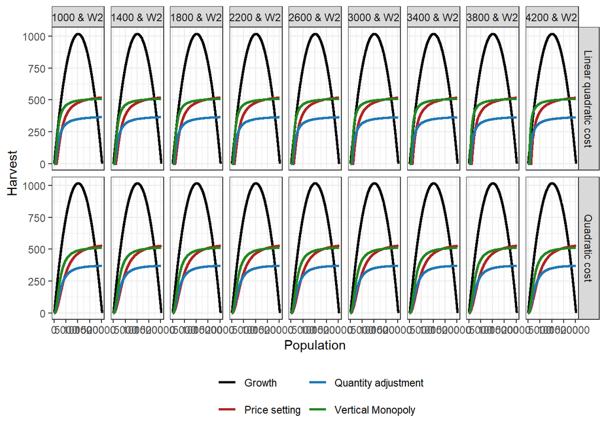

Clearly, the choice of $W_1$ and $W_2$ is important with respect to the anticipated equilibrium in the *vertical monopoly* case : with a linear-quadratic cost function, we no longer can say the monopoly will achieve a *healthy* steady state population. The results in the **post intervention** world are robust to the cost specification, and guarantee population increases in the *quantity adjustment* scenario, while population may marginally diminish in the *price setting* scenario.

#### B. Graph with prefered specification

First, illustrate the new equilibria with the same $W$ = 3.7465338 value and the prefered solution for $W_1$ and $W_2$ (e.g 12200, 0.57) in the linear quadratic cost of effort specification.

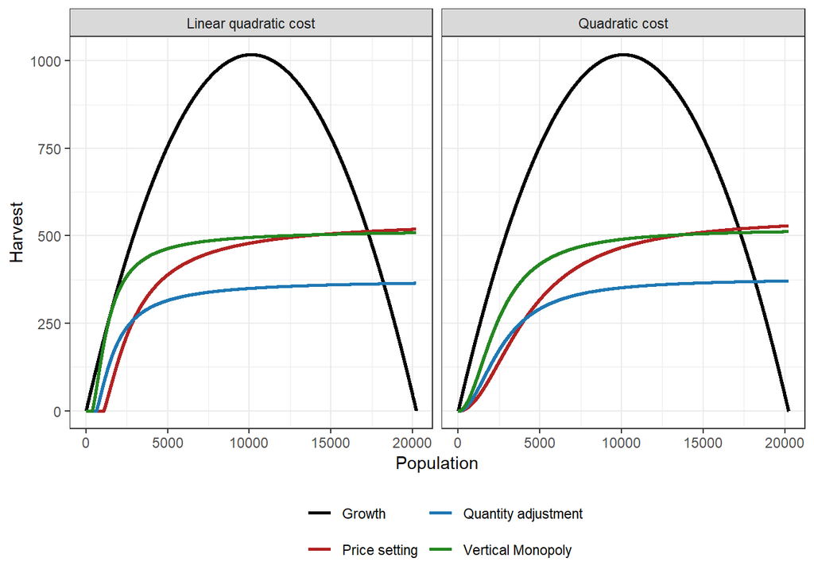

Save plot for final results :

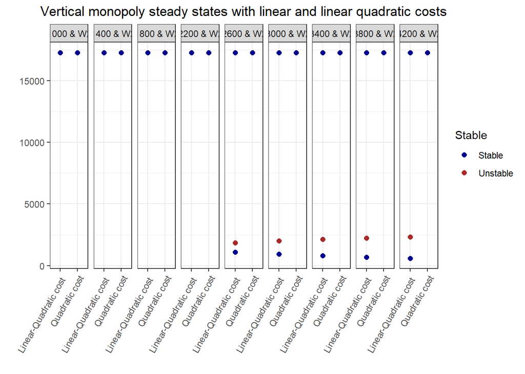

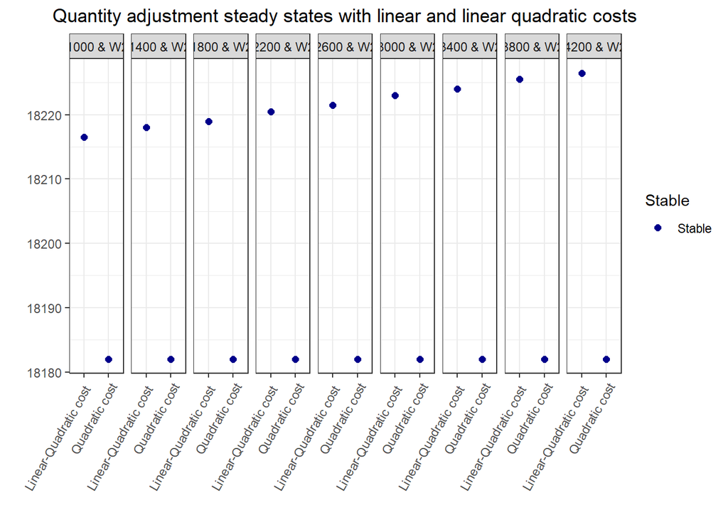

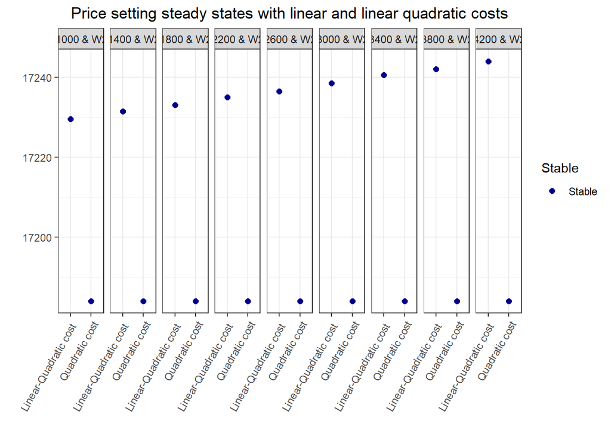

Define bio-economic performance by combining population variables (stock and harvest) with price and profit data from economic model.

| Scenario | Poached harvest (in mt) | Farmed harvest (in mt) | Steady state population (in mt) | Retail price (in USD/ton of buche) | Retail price of 500g buche (in USD) | Price paid to poacher (in USD/ton of buche) | Poacher price of 500g buche (in USD) | Illegal profit (in million USD) | Farming profit (in million USD) | Fishing profit (in million USD) | Aggregate profit (in million USD) | Aggregate profit change (in million USD) | Farming profit change (in million USD) | Illegal profit change (in million USD) | Fishing profit change (in million USD) | Variation in ss. pop. | Poaching change (%) |
| --- | --- | --- | --- | --- | --- | --- | --- | --- | --- | --- | --- | --- | --- | --- | --- | --- | --- |
| Vertical Monopoly | 509.64 | 0.00 | 17259.0 | 828894.3 | 21302.583 | 31951.60 | 821.1560 | 406.15 | 0.00 | 8.14 | 414.29 | 11.05 | 0.00 | 4.13 | 6.92 | -0.1% | 0.51% |
| Quantity adjustment | 369.87 | 330.94 | 18182.0 | 599279.2 | 15401.476 | 20894.42 | 536.9866 | 213.93 | 171.26 | 3.86 | 389.05 | -14.19 | 171.26 | -188.09 | 2.64 | 5.24% | -27.05% |
| Price setting | 520.27 | 425.30 | 17184.0 | 236298.3 | 6072.866 | 32903.89 | 845.6299 | 105.82 | 70.71 | 8.56 | 185.09 | -218.15 | 70.71 | -296.20 | 7.34 | -0.54% | 2.61% |
| Vertical Monopoly - LQ cost | 507.04 | 0.00 | 17277.0 | 832955.7 | 21406.962 | 40074.46 | 1029.9136 | 402.02 | 0.00 | 1.22 | 403.24 | 0.00 | 0.00 | 0.00 | 0.00 | 0% | 0% |
| Quantity adjustment - LQ cost | 363.71 | 333.60 | 18220.5 | 605295.6 | 15556.098 | 36537.13 | 939.0044 | 206.87 | 174.03 | 0.57 | 381.46 | -21.78 | 174.03 | -195.16 | -0.66 | 5.46% | -28.27% |
| Price setting - LQ cost | 536.70 | 430.05 | 17235.0 | 204179.1 | 5247.402 | 39870.05 | 1024.6602 | 88.18 | 58.74 | 3.57 | 150.49 | -252.75 | 58.74 | -313.84 | 2.34 | -0.24% | 5.85% |

Table for manuscript :

| Scenario | Poached harvest (in mt) | Farmed harvest (in mt) | Steady state population (in mt) | Illegal profit (in million USD) | Farming profit (in million USD) | Fishing profit (in million USD) | Aggregate profit (in million USD) | Illegal profit change (in million USD) | Variation in ss. pop. | Poaching change (%) |
| --- | --- | --- | --- | --- | --- | --- | --- | --- | --- | --- |
| Vertical Monopoly | 507.04 | 0.00 | 17277.0 | 402.02 | 0.00 | 1.22 | 403.24 | 0.00 | 0% | 0% |
| Quantity adjustment | 363.71 | 333.60 | 18220.5 | 206.87 | 174.03 | 0.57 | 381.46 | -195.16 | 5.46% | -28.27% |
| Price setting | 536.70 | 430.05 | 17235.0 | 88.18 | 58.74 | 3.57 | 150.49 | -313.84 | -0.24% | 5.85% |